# Amaya Choksi - LabCandy

```r
d = read.csv("https://raw.githubusercontent.com/tomcm39/data/master/candy-power-ranking/candy-data.csv")
print(nrow(d))
```

```
## [1] 85
```

```r
print(d)
```

[output not shown]

[output cut: 243 more lines]

## Logistic Regression Model for Caramel Candy

```r
model = glm( caramel~sugarpercent+pricepercent+crispedricewafer, data=d, family=binomial)
print(summary(model))
```

```
##
## Call:
## glm(formula = caramel ~ sugarpercent + pricepercent + crispedricewafer,
##     family = binomial, data = d)
##
## Deviance Residuals:
##     Min       1Q   Median       3Q      Max
## -1.3794  -0.6421  -0.4476  -0.2538   2.4517
##
## Coefficients:
##                  Estimate Std. Error z value Pr(>|z|)
## (Intercept)       -3.8186     1.0443  -3.657 0.000255 ***
## sugarpercent       1.9822     1.2490   1.587 0.112489
## pricepercent       1.8548     1.2796   1.450 0.147172
## crispedricewafer   0.9804     0.9126   1.074 0.282709
## ---
## Signif. codes:  0 '***' 0.001 '**' 0.01 '*' 0.05 '.' 0.1 ' ' 1
##
## (Dispersion parameter for binomial family taken to be 1)
##
##     Null deviance: 76.057  on 84  degrees of freedom
## Residual deviance: 66.803  on 81  degrees of freedom
## AIC: 74.803
##
## Number of Fisher Scoring iterations: 5
```

## Description of target variable and covariates

My model is attempting to classify candy as containing caramel or not containing caramel.I chose 3 covariates: The percentage of sugar in the candy, the unit price percentile compared to the other candy, and whether or not the candy contained crisped rice wafers.I fit a logistic regression model to my candy data.

## Description using log-odds

In terms of log-odds, the intercept equals $-3.81$, sugar percentile equals $1.99$, price percentile equals $1.86$, and whether it contains crisped wafers equals $0.98$. Candy with a higher sugar percentile,candy that is more expensive or candy that contains cripsed wafers could indicate it contains caramel (positive log-odds).

## Description of significant variables

No covariates seems to be significant. The intercept is significant. The pvalue <0.05 and indicates the estimated log-odds is unlikely to have come from a null distribution centered at a log-odds of $0$.

## PLot of the Data

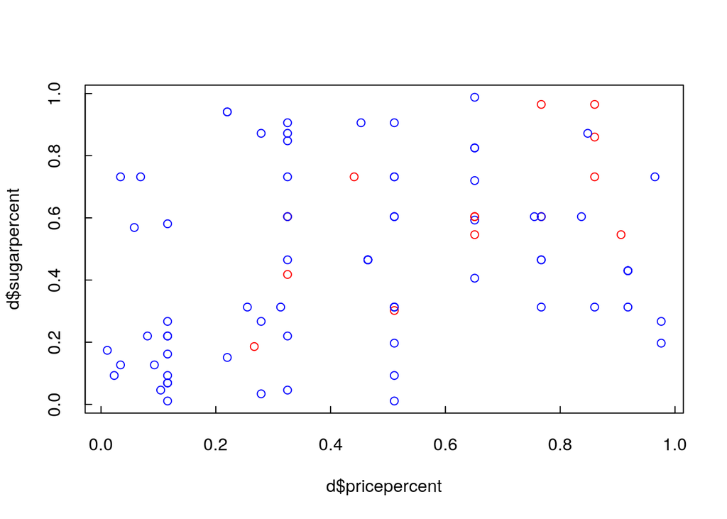

```r
colors = ifelse( d$caramel==1,'red','blue')
plot(d$pricepercent,d$sugarpercent,tck=0.02,col=colors)
```

```r
coefficients = as.matrix(coef(model))
print(coefficients)
```

```
##                        [,1]
## (Intercept)      -3.8186245
## sugarpercent      1.9822483
## pricepercent      1.8548496
## crispedricewafer  0.9803593
```

```r
xs = seq(0,1,0.01)
```

## Accuracy of the Model

```r
trainingData  = d[,c('sugarpercent','pricepercent','crispedricewafer')]
trainingData  = cbind(1,trainingData)

predictions   = as.matrix(trainingData) %*% coefficients
probabilities = exp(predictions)/(1+predictions)
decisions = ifelse(predictions>=0,1,0)

Accuracy = mean(d$caramel==decisions)
print(Accuracy)
```

```
## [1] 0.8352941
```

We can make correct guesses about whether the candy has caramel approximately 84% of the time by fitting a logistic regression model and including the sugar and price percentile, and whether the candy contains crisped rice wafer.